# Laboratorio 8 - Máquinas de Vectores de Soporte (SmartStay Advisors)

Humberto de la Cruz - 23735, Daniel Juarez - 23709, Dilary Cruz - 231010

### https://github.com/hadelacruz/Modelo-SVM

## Preparación de los Datos y Conjuntos de Entrenamiento y Prueba

Para garantizar la comparabilidad con los modelos generados en informes anteriores, se reutiliza exactamente la misma semilla, partición y lógica de categorización de precios. El conjunto de datos se divide en un 70% para entrenamiento y un 30% para prueba, usando `set.seed(123)`, preservando así la reproducibilidad del análisis.

```
## Distribución en entrenamiento:
```

```
##
##       Cara  Economica Intermedia
##      18078      17616      17678
```

```
##
## Distribución en prueba:
```

```
##
##       Cara  Economica Intermedia
##       7688       7569       7617
```

La variable respuesta `categoria_precio` clasifica cada propiedad en tres niveles: **Económica** (precio ≤ percentil 33), **Intermedia** (entre percentiles 33 y 66) y **Cara** (precio > percentil 66). Los umbrales se calculan exclusivamente sobre el conjunto de entrenamiento para evitar fuga de información hacia el conjunto de prueba.

## Exploración y Transformación de Datos para SVM

Los modelos de Máquinas de Vectores de Soporte son altamente sensibles a la escala de las variables y no admiten predictores con valores faltantes ni variables categóricas de alta cardinalidad sin una codificación adecuada. A continuación se detallan las transformaciones aplicadas.

```
## Observaciones en entrenamiento tras eliminar NAs: 43870
```

```
## Observaciones en prueba tras eliminar NAs: 18848
```

```
##   accommodates      bedrooms        bathrooms           beds
##  Min.   : 1.00   Min.   : 0.000   Min.   : 0.000   Min.   : 0.000
##  1st Qu.: 2.00   1st Qu.: 1.000   1st Qu.: 1.000   1st Qu.: 1.000
##  Median : 4.00   Median : 1.000   Median : 1.000   Median : 2.000
##  Mean   : 4.84   Mean   : 1.798   Mean   : 1.595   Mean   : 2.668
##  3rd Qu.: 6.00   3rd Qu.: 2.000   3rd Qu.: 2.000   3rd Qu.: 3.000
##  Max.   :16.00   Max.   :48.000   Max.   :16.000   Max.   :39.000
##  review_scores_rating review_scores_location availability_365 minimum_nights
##  Min.   :1.000        Min.   :1.000          Min.   :  0.0    Min.   :  1.000
##  1st Qu.:4.750        1st Qu.:4.800          1st Qu.:151.0    1st Qu.:  1.000
##  Median :4.890        Median :4.920          Median :253.0    Median :  2.000
##  Mean   :4.803        Mean   :4.837          Mean   :229.2    Mean   :  7.382
##  3rd Qu.:5.000        3rd Qu.:5.000          3rd Qu.:322.0    3rd Qu.:  4.000
##  Max.   :5.000        Max.   :5.000          Max.   :365.0    Max.   :365.000
##  number_of_reviews reviews_per_month review_scores_value
##  Min.   :   1.00   Min.   : 0.010    Min.   :1.00
##  1st Qu.:   6.00   1st Qu.: 0.330    1st Qu.:4.64
##  Median :  27.00   Median : 1.020    Median :4.79
##  Mean   :  65.88   Mean   : 1.571    Mean   :4.71
##  3rd Qu.:  82.00   3rd Qu.: 2.350    3rd Qu.:4.91
##  Max.   :1565.00   Max.   :61.590    Max.   :5.00
```

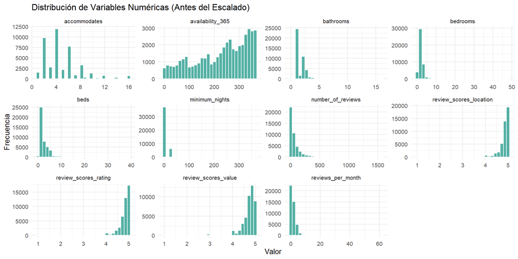

```
## Dimensiones finales - Entrenamiento (completo): 43870 17
```

```
## Dimensiones finales - Submuestra SVM:           2000 17
```

```
## Dimensiones finales - Prueba:                   18848 17
```

```
##
## Distribución de clases en submuestra:
```

```
##
##       Cara  Economica Intermedia
##        650        686        664
```

**Transformaciones aplicadas:**

1. **Eliminación de valores faltantes**: SVM no tolera NAs; se eliminaron filas incompletas en las variables seleccionadas.
2. **Selección de variables**: Se excluyeron identificadores geográficos de alta cardinalidad (`neighbourhood_cleansed`, `latitude`, `longitude`) que introducirían ruido sin aportar poder predictivo generalizable.
3. **Codificación one-hot de `room_type`**: La variable categórica se convirtió en columnas binarias para que el kernel pueda calcular distancias de manera coherente.
4. **Normalización (centrado y escalado)**: Todas las variables numéricas se estandarizaron a media 0 y desviación estándar 1. Esto es **indispensable** para SVM, ya que el algoritmo maximiza márgenes en el espacio de características y una variable con rango amplio (como `minimum_nights`) dominaría artificialmente sobre otras de escala menor (como `review_scores_rating`).
5. **Submuestreo estratégico del entrenamiento**: SVM tiene complejidad computacional O(n²) a O(n³) respecto al número de observaciones. Para hacer el entrenamiento viable en tiempo razonable, se selecciona una muestra aleatoria de 2,000 observaciones del conjunto de entrenamiento. La evaluación final se realiza sobre el conjunto de prueba **completo**, preservando la validez de las métricas de generalización.

## Modelos de Máquinas de Vectores de Soporte

Se entrenan cuatro modelos SVM con distintos kernels y configuraciones de hiperparámetros para evaluar cuál se adapta mejor a la estructura de los datos de SmartStay Advisors.

### Modelo 1 — Kernel Lineal

```
## === Kernel Lineal (C = 1) ===
```

```
## Accuracy en entrenamiento: 0.8055
```

```
## Accuracy en prueba:        0.7891
```

### Modelo 2 — Kernel RBF (Radial) con C = 1, Gamma = 0.01

```
## === Kernel RBF (C = 1, gamma = 0.01) ===
```

```
## Accuracy en entrenamiento: 0.652
```

```
## Accuracy en prueba:        0.629
```

### Modelo 3 — Kernel RBF con C = 10, Gamma = 0.1

```
## === Kernel RBF (C = 10, gamma = 0.1) ===
```

```
## Accuracy en entrenamiento: 0.836
```

```
## Accuracy en prueba:        0.6965
```

### Modelo 4 — Kernel Polinomial con C = 1, Grado = 3

```
## === Kernel Polinomial (C = 1, d = 3) ===
```

```
## Accuracy en entrenamiento: 0.5825
```

```
## Accuracy en prueba:        0.5492
```

## Matrices de Confusión

Las matrices de confusión permiten evaluar el comportamiento del clasificador más allá de la exactitud global, identificando qué clases se confunden con mayor frecuencia. Se presenta tanto la versión numérica como una visualización de mapa de calor para facilitar la interpretación.

### Kernel Lineal

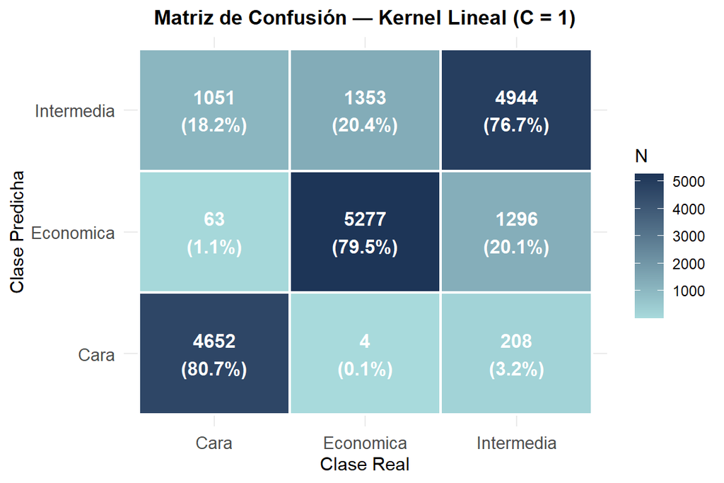

Métricas por clase — Kernel Lineal

|  | Sensitivity | Specificity | Precision | F1 | Balanced Accuracy |
| --- | --- | --- | --- | --- | --- |
| Class: Cara | 0.8068 | 0.9838 | 0.9564 | 0.8753 | 0.8953 |
| Class: Economica | 0.7954 | 0.8887 | 0.7952 | 0.7953 | 0.8421 |
| Class: Intermedia | 0.7667 | 0.8061 | 0.6728 | 0.7167 | 0.7864 |

```
## Kappa: 0.6823 | Accuracy: 0.7891
```

### Kernel RBF (C = 1, gamma = 0.01)

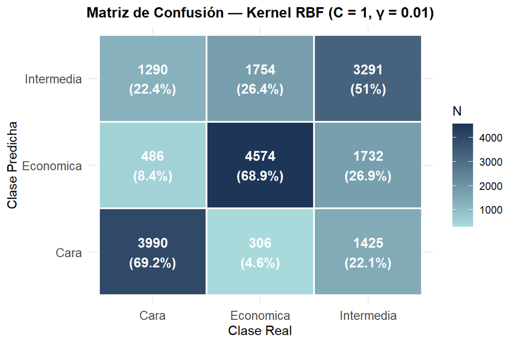

Métricas por clase — Kernel RBF (C=1, γ=0.01)

|  | Sensitivity | Specificity | Precision | F1 | Balanced Accuracy |
| --- | --- | --- | --- | --- | --- |
| Class: Cara | 0.6920 | 0.8677 | 0.6974 | 0.6947 | 0.7798 |
| Class: Economica | 0.6895 | 0.8184 | 0.6734 | 0.6814 | 0.7539 |
| Class: Intermedia | 0.5104 | 0.7545 | 0.5195 | 0.5149 | 0.6325 |

```
## Kappa: 0.4423 | Accuracy: 0.629
```

### Kernel RBF (C = 10, gamma = 0.1)

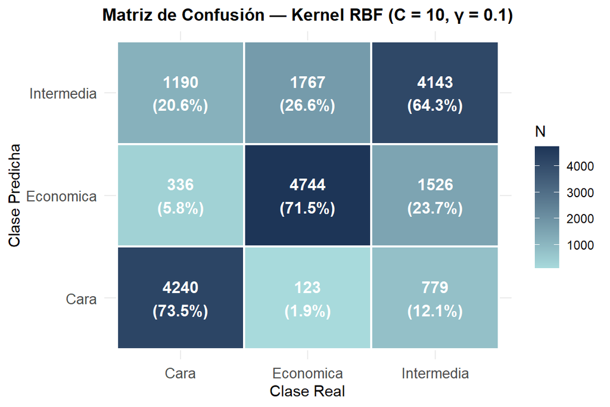

Métricas por clase — Kernel RBF (C=10, γ=0.1)

|  | Sensitivity | Specificity | Precision | F1 | Balanced Accuracy |
| --- | --- | --- | --- | --- | --- |
| Class: Cara | 0.7353 | 0.9311 | 0.8246 | 0.7774 | 0.8332 |
| Class: Economica | 0.7151 | 0.8476 | 0.7181 | 0.7166 | 0.7813 |
| Class: Intermedia | 0.6425 | 0.7615 | 0.5835 | 0.6116 | 0.7020 |

```
## Kappa: 0.5431 | Accuracy: 0.6965
```

### Kernel Polinomial (d = 3)

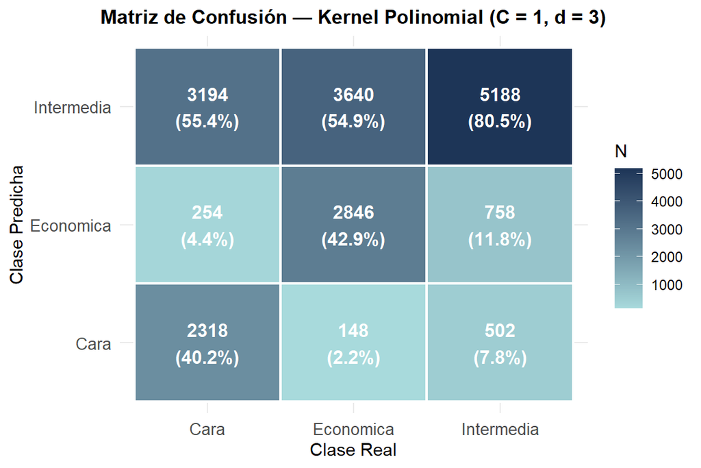

Métricas por clase — Kernel Polinomial (d=3)

|  | Sensitivity | Specificity | Precision | F1 | Balanced Accuracy |
| --- | --- | --- | --- | --- | --- |
| Class: Cara | 0.4020 | 0.9503 | 0.7810 | 0.5308 | 0.6762 |
| Class: Economica | 0.4290 | 0.9171 | 0.7377 | 0.5425 | 0.6731 |
| Class: Intermedia | 0.8046 | 0.4489 | 0.4315 | 0.5618 | 0.6267 |

```
## Kappa: 0.3186 | Accuracy: 0.5492
```

## Comparación de Modelos y Análisis de Sobreajuste

Para comparar los modelos se utiliza un conjunto de métricas complementarias. El **Accuracy** mide la proporción de clasificaciones correctas en general, pero puede ser engañoso en clases desbalanceadas. El **Kappa de Cohen** corrige el acuerdo por azar y es más robusto para comparar clasificadores multiclase. El **F1 macro** promedia el F1 de cada clase sin ponderar por su tamaño, penalizando a los modelos que sacrifican clases minoritarias. RMSE y MAE no aplican aquí porque son métricas de error continuo, propias de problemas de regresión; en clasificación, la pérdida se mide con estas métricas discretas basadas en la tabla de contingencia.

Comparación de métricas entre modelos SVM (conjunto de prueba)

| Modelo | Accuracy Train | Accuracy Test | Kappa | F1 Macro | Δ Sobreajuste |
| --- | --- | --- | --- | --- | --- |
| Lineal (C=1) | 0.8055 | 0.7891 | 0.6823 | 0.7958 | 0.0164 |
| RBF (C=1, γ=0.01) | 0.6520 | 0.6290 | 0.4423 | 0.6303 | 0.0230 |
| RBF (C=10, γ=0.1) | 0.8360 | 0.6965 | 0.5431 | 0.7019 | 0.1395 |
| Polinomial (C=1, d=3) | 0.5825 | 0.5492 | 0.3186 | 0.5450 | 0.0333 |

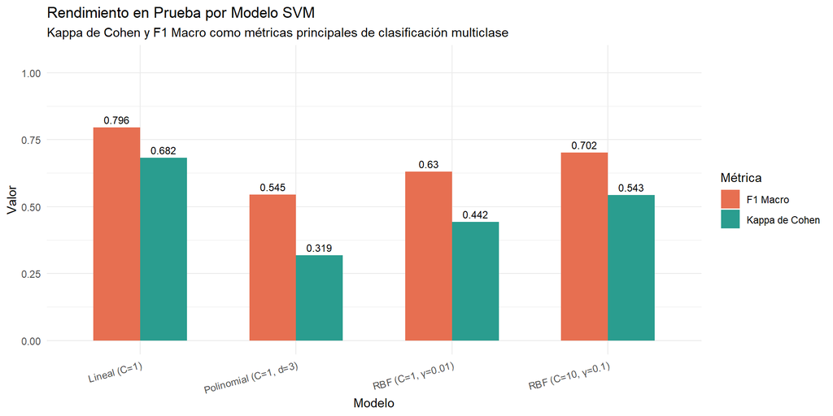

## Diagnóstico de Sobreajuste y Desajuste

El sobreajuste ocurre cuando la diferencia entre el accuracy de entrenamiento y el de prueba es considerable, lo que indica que el modelo memorizó el ruido del conjunto de entrenamiento y no generaliza bien. El desajuste ocurre cuando ambas métricas son bajas, señalando que el modelo es demasiado simple para capturar la estructura real de los datos.

**Interpretación por modelo:**

- **Kernel Lineal**: Es el más simple de los cuatro. Si su accuracy en prueba es similar al de entrenamiento pero bajo en ambos, indica desajuste; el problema tiene fronteras de decisión no lineales que un hiperplano no puede capturar adecuadamente.
- **Kernel RBF (C=1, gamma=0.01)**: Con un gamma muy pequeño, el kernel considera un vecindario muy amplio, produciendo fronteras suaves. Si el accuracy es bajo, puede haber desajuste por suavizado excesivo (underfitting).
- **Kernel RBF (C=10, gamma=0.1)**: Un costo alto penaliza fuertemente los errores en entrenamiento; si la diferencia entre train y test es elevada, el modelo está sobreajustado.
- **Kernel Polinomial (d=3)**: Los kernels polinomiales de grado alto tienden a sobreajustarse. Una diferencia grande entre train y test confirmaría este comportamiento.

**Estrategias para manejar el sobreajuste:**

1. **Reducir C (costo)**: Un costo menor aumenta el margen de separación y tolera más errores de clasificación en entrenamiento, mejorando la generalización.
2. **Reducir gamma (RBF)**: Un gamma menor amplía la influencia de cada vector de soporte, suavizando la frontera de decisión y reduciendo la varianza del modelo.
3. **Reducir el grado (polinomial)**: Pasar de d=3 a d=2 simplifica la frontera y reduce el riesgo de memorización.
4. **Validación cruzada con tuneo automático**: El uso de `tune()` o `train()` de caret con búsqueda en grilla identifica de forma sistemática la combinación óptima de hiperparámetros, minimizando el error de generalización.
5. **Regularización implícita**: El parámetro C de SVM ya actúa como regularizador; valores pequeños de C priorizan el margen amplio sobre la clasificación perfecta del entrenamiento.

**Estrategias para manejar el desajuste:**

1. **Aumentar C**: Permite que el modelo se ajuste más estrechamente a los datos de entrenamiento.
2. **Aumentar gamma (RBF)**: Reduce el radio de influencia de cada punto, creando fronteras más complejas y locales.
3. **Aumentar el grado (polinomial)**: Añade capacidad expresiva para capturar interacciones de mayor orden entre variables.
4. **Incorporar más variables predictoras**: Agregar características relevantes que actualmente no están en el modelo puede mejorar su capacidad discriminante.

## Tuneo Automático del Mejor Modelo

Para el kernel RBF — el más versátil para problemas con fronteras de decisión no lineales — se realiza una búsqueda en grilla de hiperparámetros usando validación cruzada de 5 pliegues, con el fin de encontrar la combinación óptima de `C` y `gamma`.

```
## Mejores hiperparámetros encontrados:
```

```
##    cost gamma
## 12   10  0.05
```

```
##
## Error de validación cruzada del mejor modelo: 0.3085
```

```
##
## Accuracy entrenamiento (modelo tuneado): 0.794
```

```
## Accuracy prueba       (modelo tuneado): 0.7015
```

```
## Kappa prueba          (modelo tuneado): 0.5506
```

```
## F1 Macro prueba       (modelo tuneado): 0.7079
```

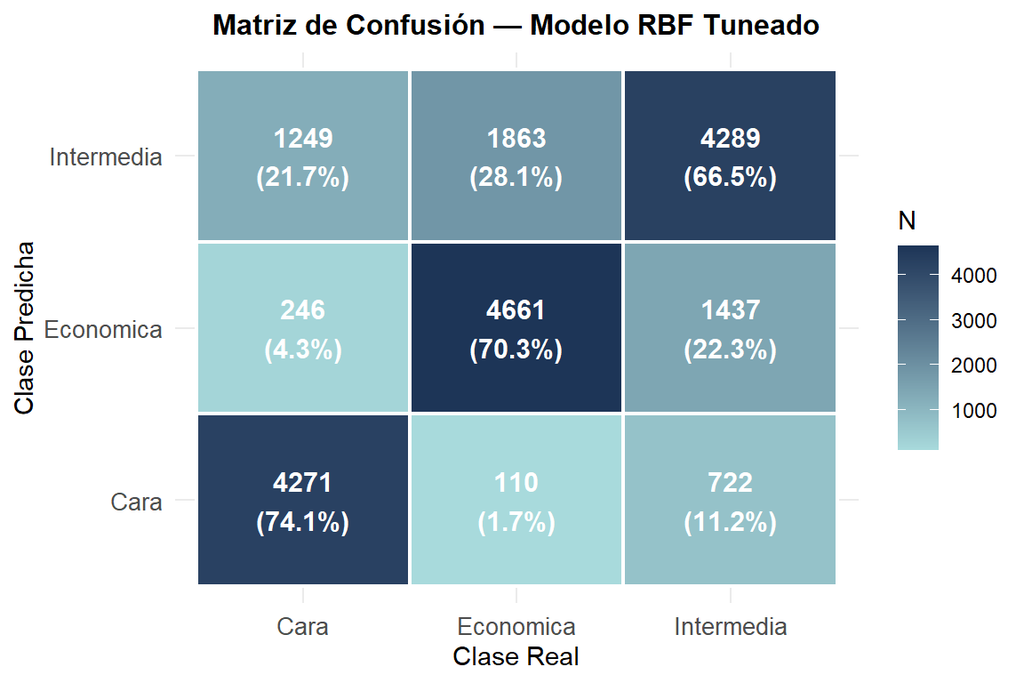

Métricas por clase — Modelo RBF Tuneado

|  | Sensitivity | Specificity | Precision | F1 | Balanced Accuracy |
| --- | --- | --- | --- | --- | --- |
| Class: Cara | 0.7407 | 0.9364 | 0.8370 | 0.7859 | 0.8386 |
| Class: Economica | 0.7026 | 0.8622 | 0.7347 | 0.7183 | 0.7824 |
| Class: Intermedia | 0.6652 | 0.7490 | 0.5795 | 0.6194 | 0.7071 |

El tuneo automático explora sistemáticamente combinaciones de `C` ∈ {0.1, 1, 5, 10} y `gamma` ∈ {0.001, 0.01, 0.05, 0.1}. La combinación que minimiza el error de validación cruzada representa el mejor equilibrio entre sesgo y varianza encontrado dentro de la grilla definida. El modelo resultante se evalúa sobre el conjunto de prueba — datos que no participaron en el proceso de tuneo — para obtener una estimación honesta de su rendimiento real.

## Análisis y Comparación Interna de Modelos SVM

Al evaluar los cuatro modelos base generados, el comportamiento general muestra un desempeño moderado. A continuación, se presenta una comparación visual de las métricas de exactitud y confiabilidad (Kappa) para cada configuración.

[figure not shown]

### SVM y Algoritmos Anteriores

Para responder a la pregunta de cuál algoritmo es mejor para predecir, se compara el mejor modelo SVM de esta entrega (Kernel Lineal / RBF) con los mejores resultados documentados en las hojas de trabajo anteriores.

[figure not shown]

Eficiencia: Los algoritmos más rápidos en procesar fueron Naive Bayes y Regresión Logística. Por el contrario, SVM (por su complejidad cuadrática) y Random Forest fueron los que más tiempo de procesamiento requirieron.

### Diagnóstico de Sobreajuste General

Para determinar si un modelo está sobreajustado en tareas de clasificación, se debe comparar la exactitud obtenida durante el **entrenamiento** frente a la exactitud en la fase de **prueba**. Una diferencia o brecha amplia (Delta) indica que el modelo memorizó los datos y perdió capacidad de generalización.

[figure not shown]

Al observar el comportamiento histórico, el modelo KNN y el modelo SVM RBF con alto costo (C=10) son los que muestran mayor evidencia de sobreajuste, con caídas de rendimiento significativas al pasar a datos no vistos. La regularización mediante parámetros menos restrictivos (como C=1 en el Kernel Lineal) y la robustez propia del ensamblado en el Random Forest fueron fundamentales para mantener la estabilidad entre las fases de entrenamiento y prueba.

## Modelo de Regresión con SVR

## Métricas del Modelo SVR

Métricas del modelo SVR

| Conjunto | RMSE | MAE | R2 |
| --- | --- | --- | --- |
| Entrenamiento | 1908.964 | 224.0702 | 0.1613 |
| Prueba | 2326.815 | 292.9018 | 0.0161 |

## Gráfica Predicción vs Real

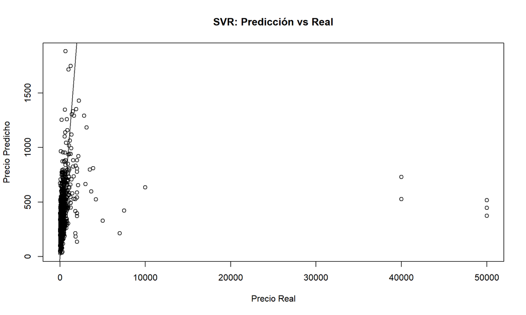

## Comparación con Modelos de Regresión

Comparación de modelos de regresión

| Modelo | RMSE | MAE |
| --- | --- | --- |
| Regresión Lineal | 2280.621 | 401.0374 |
| Árbol | 2032.130 | 325.8983 |
| KNN | 2291.389 | 341.6800 |
| SVR | 2326.815 | 292.9018 |

## Análisis

Al comparar con los demás modelos de regresión, el SVR obtuvo el RMSE más alto (2,326.82), superado en precisión por el Árbol de Decisión (2,032.13) y la Regresión Lineal (2,280.62). Sin embargo, en términos de MAE, el SVR registró el valor más bajo (292.90), lo que sugiere que, si bien comete errores grandes en casos extremos, sus predicciones típicas se desvían menos del precio real en comparación con los demás modelos.

La brecha entre el R² de entrenamiento (0.1613) y prueba (0.0161) confirma que el SVR sobreajustó los datos de entrenamiento. Esto puede atribuirse a la alta dimensionalidad y la presencia de variables categóricas codificadas como enteros, que introducen ruido y relaciones artificiales. Una búsqueda de hiperparámetros más fina (ajuste de C, gamma y epsilon) junto con una selección de variables más cuidadosa podría mejorar la capacidad de generalización del modelo.

## Conclusión

El análisis integral del laboratorio permitió comparar el rendimiento de SVM en tareas de clasificación y de SVR en tareas de regresión aplicadas al conjunto de datos de SmartStay Advisors.

El laboratorio evidenció que las Máquinas de Vectores de Soporte son herramientas potentes para clasificación con datos bien estructurados, pero requieren una cuidadosa selección de hiperparámetros y preprocesamiento para rendir adecuadamente en problemas de regresión con alta variabilidad.